# Математически основи на музиката

## Съдържание

1. Въведение
2. Физика на звука и математически основи
3. Музикални интервали и комплексни числа
4. Векторна алгебра в музикалните структури
5. Анализ на музикални сигнали
6. Вероятности и статистики в музиката
7. Заключение и приложения

## 1. Въведение

### Тематика

Музиката и математиката са тясно свързани. От древногръцките открития на Питагор до съвременните алгоритми за обработка на звук математиката предоставя фундаменталните инструменти за анализ в тази област.

**Основни въпроси:**

- Как математическите концепции обясняват физическата природа на звука?
- Какви математически структури се крият зад музикалните хармонии?
- Как можем да използваме линейна алгебра за анализ на музикални структури?
- Какви статистически модели могат да опишат музикалните предпочитания?

### Обхват на проекта

Този проект демонстрира практическото приложение на математическите концепции в областта на музиката, професионално предоставени в курса "Math Concepts for Developers - 2025" на Softuni.bg от лектор Йордан Даракчиев.

Проектът:

- Свързва важни математически понятия с основни музикални понятия;
- Показва как математически концепции са приложими за анализ на музика;
- Предоставя практически инструменти в това отношение;
- Демонстрира силата на математиката в областта на музикалното изкуство.

Този проект не дава отговор на въпроса дали математическите концепции предоставят универсални възможности за моделиране на всички процеси в музиката или са необходими и философски концепции - следваща тема за размисъл и проект :)

### Цели

**Основни цели:**

1. Математически анализ на физическата природа на звука
2. Изследване на хармоничните отношения чрез комплексни числа
3. Векторно представяне на музикални структури
4. Приложение на смятането за анализ на музикални сигнали
5. Статистически анализ на музикални данни

## 2. Физика на звука и математически основи

### 2.1 Математическо представяне на звуковите вълни

Звукът представлява механична вълна, която може да бъде описана математически като синусоидална функция:

$$f(t) = A \sin(2\pi \cdot \nu \cdot t + \phi)$$

където:

- $A$ е амплитудата (сила на звука)
- $\nu$ е честотата в Hz
- $t$ е времето
- $\phi$ е фазата

#### Суперпозиция на звукови вълни

Когато няколко звукови вълни се комбинират, резултантният сигнал се описва от принципа на суперпозицията:

$$f_{total}(t) = \sum_{i=1}^{n} A_i \sin(2\pi \nu_i t + \phi_i)$$

където:

- $n$ е броят на комбинираните вълни
- $A_i, \nu_i, \phi_i$ са амплитудата, честотата и фазата на $i$-тата вълна

**Мощност на сигнала:** $$P = \langle f^2(t) \rangle = \frac{1}{T} \int_0^T f^2(t) dt$$

**RMS амплитуда:** $$A_{RMS} = \sqrt{P} = \sqrt{\frac{1}{T} \int_0^T f^2(t) dt}$$

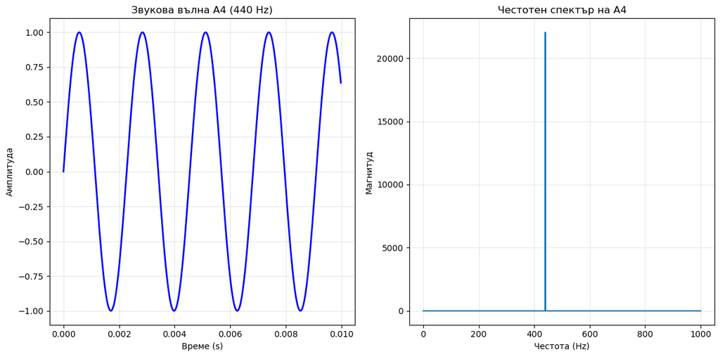

```python
import numpy as np
import matplotlib.pyplot as plt

# Параметри на звуковата вълна
sample_rate = 44100  # Hz
duration = 1.0  # секунди
frequency_A4 = 440  # Hz (нотата A4)

# Генериране на времеви масив
t = np.linspace(0, duration, int(sample_rate * duration), False)

# Генериране на синусоидална вълна за A4
wave_A4 = np.sin(2 * np.pi * frequency_A4 * t)

# Визуализация на първите 0.01 секунди
plt.figure(figsize=(12, 6))
plt.subplot(1, 2, 1)
time_zoom = t[:441]  # първите 0.01 сек
wave_zoom = wave_A4[:441]
plt.plot(time_zoom, wave_zoom, 'b-', linewidth=2)
plt.title('Звукова вълна A4 (440 Hz)')
plt.xlabel('Време (s)')
plt.ylabel('Амплитуда')
plt.grid(True, alpha=0.3)

# Честотен спектър
plt.subplot(1, 2, 2)
fft_wave = np.fft.fft(wave_A4)
frequencies = np.fft.fftfreq(len(wave_A4), 1/sample_rate)
magnitude = np.abs(fft_wave)

# Показваме само положителните честоти до 1000 Hz
positive_freq_idx = (frequencies >= 0) & (frequencies <= 1000)
plt.plot(frequencies[positive_freq_idx], magnitude[positive_freq_idx])
plt.title('Честотен спектър на A4')
plt.xlabel('Честота (Hz)')
plt.ylabel('Магнитуд')
plt.grid(True, alpha=0.3)

plt.tight_layout()
plt.show()
```